# Day 0: Intro to Git

Lewis Meineke

2020-08-25

# Introduction

We’ll mostly be following along with Software Carpentry again today, but I’ll put this little diagram of the workflow right at the top here, since I find it helps when learning the workflow.

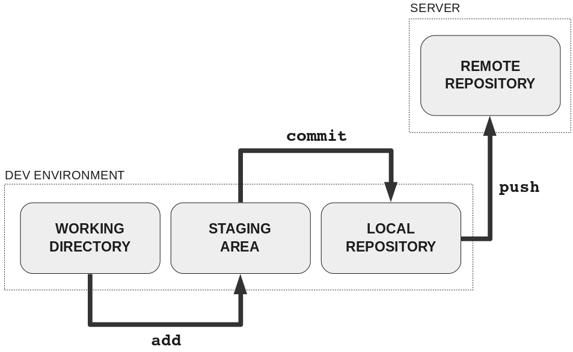

From https://rachelcarmena.github.io/2018/12/12/how-to-teach-git.html

### Today’s goals

- Introduce you to the git workflow and ensure that you understand:
  - Local git repositories
  - Remote git repositories
  - Staging, tracking, committing, and pushing
  - Reviewing repository history
  - Branching and merging, at least conceptually (we may not get into detail)
- Connect you to resources for continuing to learn git, GitHub, and how to integrate them into your actual workflows

### But I already know git!

Okay, then study the [visual reference](https://marklodato.github.io/visual-git-guide/index-en.html) to make **really** sure you know it.

# Set up git

[**Download and install git.**](https://git-scm.com/download/) It’s okay to accept the default options in the installer.

- Windows users: you definitely want the default behavior to automatically handle line endings. If you didn’t do this during installation, that’s okay, you can change the setting like this:

  ```bash
  $ git config --global core.autocrlf true
  ```

## One-time setup

```bash
$ git config --global user.name 'My Name'
$ git config --global user.email 'my@email.edu'
```

## Cheat sheet of our core git commands for today

`git init`: Creates a new, empty git repository in the current directory.

`git status`: Tells you what branch you’re on, what files are in the staging area, and what untracked files are in your repo, plus some other useful information. Doesn’t make any changes.

`git log`: Summarizes the commit history for your repo. Doesn’t change anything.

`git add`: Adds an untracked/unstaged file to your staging area.

`git commit`: Commits the changes in the staging area

`git clone`: Gets a repo from a remote source, makes a copy of it locally, and sets it up to track the remote repo.

`git pull`: Updates the local repo with any new commits that have been made on the remote repo.

`git push`: Updates the remote repo with any new commits you’ve made on the local repo.

# Resources for learning git

Take your time learning git! It’s absolutely critical but also sort of complex and unintuitive. I recommend going through one intro course on your own and then doing another one on the same material, just to make sure you really understand the concepts.

[Learn Git Branching](https://learngitbranching.js.org/) is a very popular graphical walkthrough. Git really lends itself to visual learning.

[Learn Enough Git to be Dangerous](https://www.learnenough.com/git-tutorial) is great for developing a practical understanding of the parts of Git that you really need to know. I highly recommend working through it (along with his other tutorials on the shell and text editors) to really get a solid grasp on these tools.

[GitHub Learning Lab](https://lab.github.com/) is excellent for getting familiar with the GitHub interface. It’s not really targeted at getting you to understand git, though–remember, GitHub is a separate service that uses git, but it’s not actually part of git itself.

[GitHub’s resource page](https://try.github.io/) has some links to useful resources including cheatsheets and visualizations.

Even though it’s called [How to Teach Git](https://rachelcarmena.github.io/2018/12/12/how-to-teach-git.html), this page has a bunch more handy diagrams to help you understand things.

I also recommend checking out NUIT’s [Git resource list](https://github.com/nuitrcs/gitworkshop).

If you start to get bewildered with some of the finer points of git, there’s a [fake git manual page generator](https://git-man-page-generator.lokaltog.net/#) to reassure you that you are not alone.